# OPENFLEX before and after Ξ-consistent recalibration

Retained trajectories, temporary expenditure pulses and limits of feedback identification

Author

LEEDS_MODEL research notes

Published

October 2, 2026

## Object and findings

This report compares two EU/RoW OPENFLEX experiments with adaptive expectations θ=1 and portfolio return sensitivity σ=0. The original e=0.222233 trajectory is retained; the new e=0.219545 experiment uses the authorized Ξ-consistent premium and accompanying calibrated instruments. They are separately cached, with distinct launch source/options receipts. Neither enters the accepted scenario grid.

**Measured:** both experiments reach period 100 and clear the foreign-bill market accurately, yet the quote diverges and financial holdings eventually become negative. The new fitted ordinary growth is lower by about 0.182 percentage points per period; this does not stabilize the model. The quote is RoW currency per EU currency; fitted growth concerns |xr−1| over t5–100.

| tag | e | last_period | xr_last | ordinary_growth_pct | max_scaled_clearing_gap | first_negative_EU_CB | first_negative_RoW_HH |
| --- | --- | --- | --- | --- | --- | --- | --- |
| 20261002 | 0.222233 | 100 | 12951.42 | 14.79921 | 0 | 55 | 83 |
| 20261002_xi | 0.219545 | 100 | 11301.78 | 14.61730 | 0 | 56 | 84 |

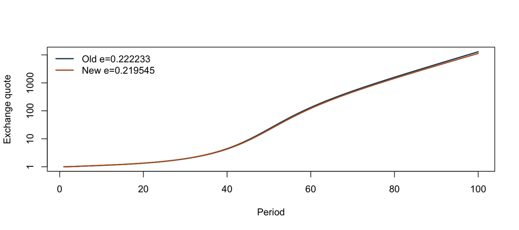

Two distinct retained experiments: RoW currency per EU currency, logarithmic vertical scale.

The new EU central bank’s own-bill holdings first become negative at period 56 and RoW households’ own-bill holdings at period 84, one period later than in the old trajectory. Numerical clearing and finite output do not establish attraction or institutional admissibility.

## Feasible expenditure disturbances on the new cache

At t9 increase either region’s real government spending by 1e-4 or 1e-5 of its baseline level. At t10 remove the carried spending increment, returning spending to baseline. Solve the full states through t20, carrying the updated Armington technique and every stock/flow rather than selecting an isolated wealth or debt coordinate. Report responses per unit of the initial real spending increment, not baseline percentages.

The solver reproduces the new cached states at t10 and t20 using both 130 and 260 inner sweeps:

| t | sweeps | scaled_cache_error | gap | step |
| --- | --- | --- | --- | --- |
| 10 | 130 | 5e-12 | 0 | 0 |
| 10 | 260 | 5e-12 | 0 | 0 |
| 20 | 130 | 5e-12 | 0 | 0 |
| 20 | 260 | 5e-12 | 0 | 0 |

The maximum scaled saved-state discrepancy is below 5.4e-12. Scaling divides each discrepancy by max(1, |saved value|). This validates selected-period reproduction; it does not certify an entire transition matrix.

The table compares quote responses at t10 and t20. Absolute amplification is |response(t20)/response(t10)|. Relative amplification additionally divides by the reference quote’s own t20/t10 change.

| tag | channel | pulse_region | quote_response_t10 | quote_response_t20 | absolute_amplification | relative_quote_amplification |
| --- | --- | --- | --- | --- | --- | --- |
| 20261002 | live Xi | Z1 | -0.0023790 | -0.0054637 | 2.296687 | 1.909840 |
| 20261002 | live Xi | Z2 | 0.0006928 | 0.0016032 | 2.313998 | 1.924236 |
| 20261002 | reference-path Xi | Z1 | -0.0020374 | -0.0051930 | 2.548830 | 2.119513 |
| 20261002 | reference-path Xi | Z2 | 0.0005941 | 0.0015242 | 2.565676 | 2.133521 |
| 20261002_xi | live Xi | Z1 | -0.0023811 | -0.0053875 | 2.262624 | 1.883200 |
| 20261002_xi | live Xi | Z2 | 0.0006941 | 0.0015819 | 2.278904 | 1.896750 |
| 20261002_xi | reference-path Xi | Z1 | -0.0020413 | -0.0051502 | 2.522969 | 2.099887 |
| 20261002_xi | reference-path Xi | Z2 | 0.0005958 | 0.0015126 | 2.538893 | 2.113141 |

Both new-cache pulse origins leave growing quote deviations after spending has returned to baseline, including relative to the rising baseline quote. Repeating with tenfold smaller pulses tests the finite-difference approximation:

| region | max_quote_response_relative_difference |
| --- | --- |
| Z1 | 4.762e-05 |
| Z2 | 4.390e-05 |

|  | quantity | maximum_absolute |
| --- | --- | --- |
| gap | FX clearing gap | 0.00000e+00 |
| quote_reciprocity | Quote reciprocity residual | 0.00000e+00 |
| world_cab | Converted world CAB residual | 0.00000e+00 |
| gold_change | Gold change | 0.00000e+00 |
| eu_bill_residual | EU redundant bill residual | 3.72434e-07 |

The full solved states satisfy reciprocal quotes, FX clearing, fixed gold and converted world current-account balance to the reported precision. A small inherited redundant EU bill residual remains; it is not silently projected away. These are finite-window economically generated disturbances with the listed constraints, not proof that every eigenmode is admissible or that no later recovery occurs.

## Is Ξ’s response to deviations necessary for these pulses?

A second branch makes production-price currency conversion Ξ follow the unperturbed quote at each period, while other current-quote readers remain active and the disturbed economy clears at its own quote. This preserves the baseline path while removing Ξ’s response to deviations. It is diagnostic channel ablation: it deliberately breaks the normal currency-conversion relation in the disturbed state and must not become an accepted alternative arm.

The reference-path Ξ branches still amplify the quote deviations between t10 and t20. Thus Ξ’s response to deviations is not necessary for these early spending-pulse amplifications in either calibration. Other wealth revaluation, fiscal/current-account and fixed foreign-portfolio channels remain active. Since the reference-path Ξ still changes over time, this experiment does not remove all currency-conversion effects or identify a sole cause of the original long trajectory.

## What remains unidentified

The old same-cache feedback report supplies partially constrained local spectra at t10/t20. These roots belong to the old experiment; no old root or growth rate is assigned to the new calibration. No mode is forced to equal the fitted trajectory multiplier. Frozen-time eigenvalues on a drifting trajectory are not the product of its changing transitions.

The present checks close the finite-window feasible-pulse comparison under the new calibration. Complete financial/balance-sheet constraint reduction, a minimal causal loop and longer admissible disturbed paths remain open. Neither the small reduction in fitted growth nor the ablation supports a canonical stabilization change. Full original G&L/EViews equation-system retrieval remains incomplete; the narrower role of 12.91FL is documented in the existing same-cache report.

## Provenance and reproduction

|  | tag | cache | sha256 |
| --- | --- | --- | --- |
| 20261002 | 20261002 | output/scenarios/arms/revised_openflex/runs/baseline_theta1_sigma0.RDS | 28c4842b7737420b7337621f3a0143423e7aea9976323dd3b89a9d4b5889f52e |
| 20261002_xi | 20261002_xi | output/scenarios/arms/revised_openflex/runs/baseline_theta1_sigma0_xi20261002.RDS | 80dc540620c1ddd971c2c4a68fa3a95959140518445521ef9dba6789ae257471 |

Launch metadata is retained beside each cache and in `openflex_decompose_<tag>_provenance.json`. Later extraction source hashes are recorded separately. The original cache’s SHA-256 remains `28c4842b7737420b7337621f3a0143423e7aea9976323dd3b89a9d4b5889f52e`.

Re-extract the new trajectory with:

```bash
Rscript R/dynamics/openflex_decompose.R --date 20261002_xi \
  --cache output/scenarios/arms/revised_openflex/runs/baseline_theta1_sigma0_xi20261002.RDS \
  --memo-prices
```

Run `R/dynamics/openflex_feasible_pulse.R` with `--arm revised_openflex`, the new cache as `--rds`, its extraction provenance as `--provenance` and separate `--out-dir output/calibration/openflex_local_20261002_xi`; repeat with `--freeze-xi`. If a launch source has since changed, restore its verified bytes in an isolated source tree and add `--source-root`. This session used `/private/tmp/leeds-xi-launch-source`; all 21 recorded hashes matched before diagnostics. It includes the original extraction script for launch validation, while the current extraction script’s JSON-name handling fix is recorded separately.

Durable tables and branch receipts are under `output/calibration/openflex_local_20261002_xi/`. The earlier `2026-10-02-openflex-same-cache-feedback` report remains the detailed account of the old experiment. Accepted baselines and scenario caches were not modified by these diagnostics.